# HW2 Automating Reviews in Medicine

Anna Prades

4 juliol de 2015

The medical literature is enormous. Pubmed, a database of medical publications maintained by the U.S. National Library of Medicine, has indexed over 23 million medical publications. Further, the rate of medical publication has increased over time, and now there are nearly 1 million new publications in the field each year, or more than one per minute.

The large size and fast-changing nature of the medical literature has increased the need for reviews, which search databases like Pubmed for papers on a particular topic and then report results from the papers found. While such reviews are often performed manually, with multiple people reviewing each search result, this is tedious and time consuming. In this problem, we will see **how text analytics can be used to automate the process of information retrieval**.

The dataset consists of the titles (variable title) and abstracts (variable abstract) of papers retrieved in a Pubmed search. Each search result is labeled with **whether the paper is a clinical trial testing a drug therapy for cancer (variable trial)**. These labels were obtained by two people reviewing each search result and accessing the actual paper if necessary, as part of a literature review of clinical trials testing drug therapies for advanced and metastatic breast cancer.

# Problem 1

## Loading the data

Load clinical_trial.csv into a data frame called trials (remembering to add the argument stringsAsFactors=FALSE), and investigate the data frame with summary() and str().

IMPORTANT NOTE: Some students have been getting errors like “invalid multibyte string” when performing certain parts of this homework question. If this is happening to you, use the argument fileEncoding=“latin1” when reading in the file with read.csv. This should cause those errors to go away.

We can use R’s string functions to learn more about the titles and abstracts of the located papers. The nchar() function counts the number of characters in a piece of text. Using the nchar() function on the variables in the data frame, answer the following questions:

How many characters are there in the longest abstract? (Longest here is defined as the abstract with the largest number of characters.)

```r
trials <- read.csv("clinical_trial.csv", stringsAsFactors = FALSE)
summary(trials)
```

```
##     title             abstract             trial
##  Length:1860        Length:1860        Min.   :0.0000
##  Class :character   Class :character   1st Qu.:0.0000
##  Mode  :character   Mode  :character   Median :0.0000
##                                        Mean   :0.4392
##                                        3rd Qu.:1.0000
##                                        Max.   :1.0000
```

```r
str(trials)
```

```
## 'data.frame':    1860 obs. of  3 variables:
##  $ title   : chr  "Treatment of Hodgkin's disease and other cancers with 1,3-bis(2-chloroethyl)-1-nitrosourea (BCNU; NSC-409962)." "Cell mediated immune status in malignancy--pretherapy and post-therapy assessment." "Neoadjuvant vinorelbine-capecitabine versus docetaxel-doxorubicin-cyclophosphami…
##  $ abstract: chr  "" "Twenty-eight cases of malignancies of different kinds were studied to assess T-cell activity and population before and after in"| __truncated__ "BACKGROUND: Among breast cancer patients, nonresponse to initial neoadjuvant chemotherapy is associated with unfavorable outcom"| …
##  $ trial   : int  1 0 1 1 1 0 1 0 0 0 ...
```

```r
# How many characters are there in the longest abstract?
max(nchar(trials$abstract))
```

```
## [1] 3708
```

```r
summary(nchar(trials$abstract))
```

```
##    Min. 1st Qu.  Median    Mean 3rd Qu.    Max.
##       0    1196    1583    1481    1821    3708
```

```r
# How many search results provided no abstract?
         table(nchar(trials$abstract) == 0)
```

```
##
## FALSE  TRUE
##  1748   112
```

```r
 #Or
         sum(nchar(trials$abstract) == 0)
```

```
## [1] 112
```

```r
 #Or
         str(subset(trials, nchar(trials$abstract) == 0))
```

```
## 'data.frame':    112 obs. of  3 variables:
##  $ title   : chr  "Treatment of Hodgkin's disease and other cancers with 1,3-bis(2-chloroethyl)-1-nitrosourea (BCNU; NSC-409962)." "Surgical adjuvant chemotherapy in cancer of the breast: results of a decade of cooperative investigation." "Occurrence of stroke with tamoxifen in NSABP B-24." "Grow…
##  $ abstract: chr  "" "" "" "" ...
##  $ trial   : int  1 0 0 0 0 0 0 0 0 0 ...
```

```r
# What is the shortest title of any article?
        which.min(nchar(trials$title))
```

```
## [1] 1258
```

```r
        trials$title[1258]
```

```
## [1] "A decade of letrozole: FACE."
```

```r
        #Or
        trials$title[which.min(nchar(trials$title))]
```

```
## [1] "A decade of letrozole: FACE."
```

Because we have both title and abstract information for trials, we need to build two corpera instead of one. Name them corpusTitle and corpusAbstract.

```r
# 1) Convert the title variable to corpusTitle and the abstract variable to corpusAbstract.
        library(tm)
        corpusTitle <- Corpus(VectorSource(trials$title))
        corpusAbstract <- Corpus(VectorSource(trials$abstract))
#2) Convert corpusTitle and corpusAbstract to lowercase. After performing this step, remember to run the lines to convert them to Plaintext
        corpusTitle = tm_map(corpusTitle, tolower)
        strwrap(corpusTitle[[1]])
```

```
## [1] "treatment of hodgkin's disease and other cancers with"
## [2] "1,3-bis(2-chloroethyl)-1-nitrosourea (bcnu; nsc-409962)."
```

```r
        corpusAbstract <- tm_map(corpusAbstract, tolower)
        corpusTitle = tm_map(corpusTitle, PlainTextDocument)
        corpusAbstract = tm_map(corpusAbstract, PlainTextDocument)
 #3) 3) Remove the punctuation in corpusTitle and corpusAbstract.
        corpusTitle = tm_map(corpusTitle, removePunctuation)
        strwrap(corpusTitle[[1]])
```

```
## [1] "treatment of hodgkins disease and other cancers with"
## [2] "13bis2chloroethyl1nitrosourea bcnu nsc409962"
```

```r
        corpusAbstract <- tm_map(corpusAbstract, removePunctuation)
#4) Remove the English language stop words from corpusTitle and corpusAbstract.
        corpusTitle =  tm_map(corpusTitle, removeWords, stopwords("english"))
        strwrap(corpusTitle[[1]])
```

```
## [1] "treatment hodgkins disease cancers 13bis2chloroethyl1nitrosourea"
## [2] "bcnu nsc409962"
```

```r
        corpusAbstract <-  tm_map(corpusAbstract, removeWords, stopwords("english"))

         #When removing stop words, use tm_map(corpusTitle, removeWords, sw) and tm_map(corpusAbstract,           removeWords, sw) instead of tm_map(corpusTitle, removeWords, stopwords("english")) and                      tm_map(corpusAbstract, removeWords, stopwords("english")).

# 5) Stem the words in corpusTitle and corpusAbstract (each stemming might take a few minutes)
        corpusTitle =  tm_map(corpusTitle,  stemDocument)
        strwrap(corpusTitle[[1]])
```

```
## [1] "treatment hodgkin diseas cancer 13bis2chloroethyl1nitrosourea bcnu"
## [2] "nsc409962"
```

```r
        corpusAbstract <-  tm_map(corpusAbstract,  stemDocument)
 # 6) Build a document term matrix called dtmTitle from corpusTitle and dtmAbstract from corpusAbstract.
        dtmTitle <- DocumentTermMatrix(corpusTitle)
        dtmAbstract <- DocumentTermMatrix(corpusAbstract)
# 7) Limit dtmTitle and dtmAbstract to terms with sparseness of at most 95% (aka terms that appear in at least 5% of documents).
        dtmTitle <- removeSparseTerms(dtmTitle, 0.95) #terms that at least appear in 5% of the documents
        dtmAbstract <- removeSparseTerms(dtmAbstract, 0.95)
# 8) Convert dtmTitle and dtmAbstract to data frames (keep the names dtmTitle and dtmAbstract).
        dtmTitle <- as.data.frame(as.matrix(dtmTitle))
        dtmAbstract <- as.data.frame(as.matrix(dtmAbstract))
        #Check  length(stopwords("english")) returns 174 -> if not -> different script provided in course
# How many terms remain in dtmTitle after removing sparse terms (aka how many columns does it have)?
        ncol(dtmAbstract)
```

```
## [1] 335
```

```r
        ncol(dtmTitle)
```

```
## [1] 31
```

# Building a Model

```r
#Using cbind(), combine dtmTitle and dtmAbstract into a single data frame called dtm:
        dtm = cbind(dtmTitle, dtmAbstract) #there is a warning
# We want to combine dtmTitle and dtmAbstract into a single data frame to
# make predictions. However, some of the variables in these data frames have
# the same names.

        colnames(dtmTitle) <- paste0("T", colnames(dtmTitle))
        colnames(dtmAbstract) <- paste0("A", colnames(dtmAbstract))
        colnames(dtmTitle)
```

```
##  [1] "Tadjuv"           "Tadvanc"          "Tbreast"
##  [4] "Tcancer"          "Tchemotherapi"    "Tclinic"
##  [7] "Tcombin"          "Tcompar"          "Tcyclophosphamid"
## [10] "Tdocetaxel"       "Tdoxorubicin"     "Tearli"
## [13] "Teffect"          "Tgroup"           "Tiii"
## [16] "Tmetastat"        "Tpatient"         "Tphase"
## [19] "Tplus"            "Tpostmenopaus"    "Trandom"
## [22] "Trandomis"        "Trespons"         "Tresult"
## [25] "Tstudi"           "Ttamoxifen"       "Ttherapi"
## [28] "Ttreatment"       "Ttrial"           "Tversus"
## [31] "Twomen"
```

```r
        dtm = cbind(dtmTitle, dtmAbstract)
#add the dependent variable "trial" to dtm
        dtm$trial <- trials$trial
#how many columns are there in this new dataframe?
        dim(dtm)
```

```
## [1] 1860  367
```

Set the random seed to 144 and use the sample.split function from the caTools package to split dtm into data frames named “train” and “test”, putting 70% of the data in the training set.

```r
set.seed(144)
        library(caTools)
        spl = sample.split(dtm$trial, SplitRatio = 0.7)
        train <- subset(dtm, spl == TRUE)
        test <- subset(dtm, spl == FALSE)
#What is the accuracy of the baseline model on the training set?
        table(train$trial)
```

```
##
##   0   1
## 730 572
```

```r
        prop.table(table(train$trial)) #0.5606759
```

```
##
##         0         1
## 0.5606759 0.4393241
```

Build a CART model called trialCART, using all the independent variables in the training set to train the model, and then plot the CART model. Just use the default parameters to build the model (don’t add a minbucket or cp value). Remember to add the method=“class” argument, since this is a classification problem.

```r
#Build a CART model
        library(rpart)
```

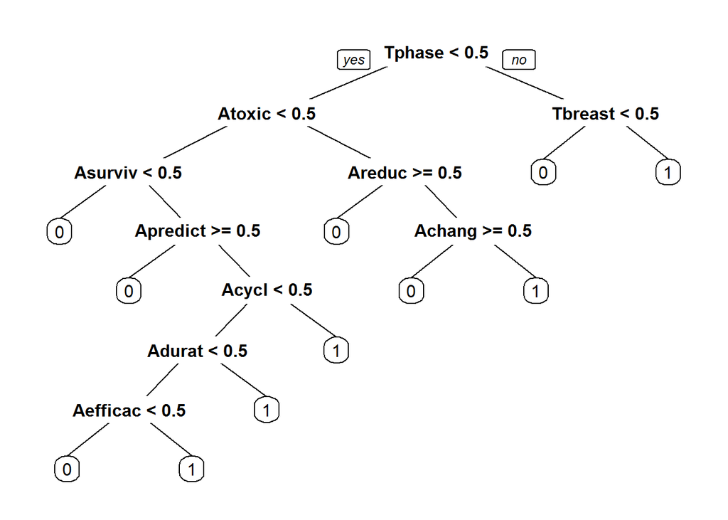

```r
        library(rpart.plot)
        trialCART <- rpart(trial ~ ., data = train, method ="class")
        prp(trialCART)
```

```r
#What is the name of the first variable the model split on?
```

Obtain the training set predictions for the model (do not yet predict on the test set). Extract the predicted probability of a result being a trial (recall that **this involves not setting a type argument**, and keeping only the second column of the predict output). What is the maximum predicted probability for any result?

```r
predTrain = predict(trialCART, newdata=train, method="class")
predTrain = predTrain[, 2]
max(predTrain)
```

```
## [1] 0.8718861
```

```r
# Alternatively, we could have done:
predTrain = predict(trialCART)[,2]
summary(predTrain)
```

```
##    Min. 1st Qu.  Median    Mean 3rd Qu.    Max.
## 0.05455 0.13640 0.28750 0.43930 0.78230 0.87190
```

Because the CART tree assigns the same predicted probability to each leaf node and there are a small number of leaf nodes compared to data points, **we expect exactly the same maximum predicted probability**.

```r
#What is the training set accuracy of the CART model?
#use a threshold probability of 0.5 to predict that an observation is a clinical trial
t1 <- table(train$trial, predTrain > 0.5)
t1
```

```
##
##     FALSE TRUE
##   0   631   99
##   1   131  441
```

```r
accuracy <- sum(diag(t1))/margin.table(t1)
accuracy
```

```
## [1] 0.8233487
```

```r
sensitivity <- t1[2,2]/(t1[2,1] + t1[2,2])#TP/(TP+FN)
sensitivity
```

```
## [1] 0.770979
```

```r
specificity <- t1[1,1]/(t1[1,1]+t1[1,2]) #TN /(TN + FP)
specificity
```

```
## [1] 0.8643836
```

# Evaluating the model on the testing set

```r
#What is the training set sensitivity of the CART model?
predTest = predict(trialCART, newdata=test, method="class")
predTest <- predTest[ ,2]
t2 <- table(test$trial, predTest > 0.5)
t2
```

```
##
##     FALSE TRUE
##   0   261   52
##   1    83  162
```

```r
accuracy <- sum(diag(t2))/margin.table(t2)
accuracy #0.7580645
```

```
## [1] 0.7580645
```

```r
sensitivity <- t2[2,2]/(t2[2,1] + t2[2,2])#TP/(TP+FN)
sensitivity
```

```
## [1] 0.6612245
```

```r
#What is the training set specificity of the CART model?
specificity <- t2[1,1]/(t2[1,1]+t2[1,2]) #TN /(TN + FP)
specificity
```

```
## [1] 0.8338658
```

```r
#Using the ROCR package, what is the testing set AUC of the prediction model?
library(ROCR)
```

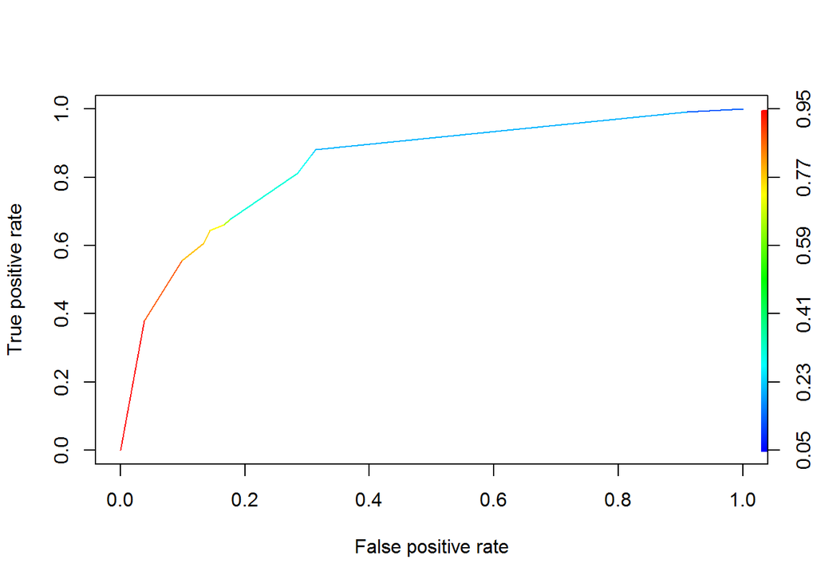

```r
predROCR = prediction(predTest, test$trial)
perfROCR = performance(predROCR, "tpr", "fpr")
plot(perfROCR, colorize=TRUE)
```

```r
# Compute AUC
performance(predROCR, "auc")@y.values #0.8371063 It has good discrimination power
```

```
## [[1]]
## [1] 0.8371063
```

# Decision maker trade-offs

**What is the cost associated with the model in Step 1 making a false negative prediction?** A paper that should have been included in Set A will be missed, affecting the quality of the results of Step 3. ** What is the cost associated with the model in Step 1 making a false positive prediction? **A paper will be mistakenly added to Set A, yielding additional work in Step 2 of the process but not affecting the quality of the results of Step 3.** Consequently, false negative should be avoided more than false positives**

[output not shown]

[output not shown]